# Employee Turnover Analytics

A Guided Machine Learning Analysis for Portobello Tech

**Analyst:** David Farmer  
**Project type:** Classification, clustering, and employee-retention analysis  
**Dataset:** `HR_comma_sep.csv`  
**Target:** `left` — 0 = stayed, 1 = left

## How to use this notebook

This notebook follows the problem statement in the same numbered order. Every assignment question has three blocks:

1. **Question block** — what the assignment asks and what the output should show.
2. **Work block** — the code cell where the analysis will be written.
3. **Interpretation checkpoint** — the explanation that turns an output into an answer.

> Work from top to bottom. Complete and verify one numbered question before moving to the next. The notebook intentionally provides structure and prompts rather than finished solutions.

## Project roadmap

| Section | Requirement | Main deliverable |
| --- | --- | --- |
| 1 | Data quality | Missing-value, duplicate, type, and range checks |
| 2 | Exploratory data analysis | Correlation heatmap and turnover-focused plots |
| 3 | Employee clustering | Three K-means clusters for employees who left |
| 4 | Preprocessing and SMOTE | Encoded features, stratified split, balanced training data |
| 5 | Model training | Logistic Regression, Random Forest, Gradient Boosting |
| 6 | Model selection | ROC/AUC, confusion matrices, metric justification |
| 7 | Retention strategy | Turnover probabilities, risk zones, targeted actions |

## 0. Environment and Data Setup

```python
from pathlib import Path
from importlib.util import find_spec
import warnings

import numpy as np
import pandas as pd
import matplotlib.pyplot as plt
import seaborn as sns

warnings.filterwarnings("ignore")
sns.set_theme(style="whitegrid", context="notebook")
pd.set_option("display.max_columns", None)

required_packages = ["sklearn", "imblearn"]
missing_packages = [name for name in required_packages if find_spec(name) is None]
print("Missing packages:", missing_packages or "None")
# If imblearn is missing, run this once in a separate cell: %pip install imbalanced-learn
```

```
Missing packages: None
```

```python
candidate_paths = [
    Path("data/raw/HR_comma_sep.csv"),
    Path("HR_comma_sep.csv"),
    Path("project_sources/03-HR_comma_sep.csv"),
]

DATA_PATH = next(
    (path for path in candidate_paths if path.exists()),
    None
)

if DATA_PATH is None:
    raise FileNotFoundError(
        "Could not find HR_comma_sep.csv in any expected location."
    )

print(f"Using dataset: {DATA_PATH.resolve()}")
```

```
Using dataset: C:\Developer\Python\Projects\Simplilearn\Microsoft_AI_Engineer\Machine Learning using Python\Employee-Turnover-Analytics\data\raw\HR_comma_sep.csv
```

```python
df = pd.read_csv(DATA_PATH)
print(f"Rows: {df.shape[0]:,} | Columns: {df.shape[1]}")
display(df.head())
```

```
Rows: 14,999 | Columns: 10
```

|  | satisfaction_level | last_evaluation | number_project | average_montly_hours | time_spend_company | Work_accident | left | promotion_last_5years | sales | salary |
| --- | --- | --- | --- | --- | --- | --- | --- | --- | --- | --- |
| 0 | 0.38 | 0.53 | 2 | 157 | 3 | 0 | 1 | 0 | sales | low |
| 1 | 0.80 | 0.86 | 5 | 262 | 6 | 0 | 1 | 0 | sales | medium |
| 2 | 0.11 | 0.88 | 7 | 272 | 4 | 0 | 1 | 0 | sales | medium |
| 3 | 0.72 | 0.87 | 5 | 223 | 5 | 0 | 1 | 0 | sales | low |
| 4 | 0.37 | 0.52 | 2 | 159 | 3 | 0 | 1 | 0 | sales | low |

### Dataset dictionary and naming notes

| CSV column | Meaning | Important note |
| --- | --- | --- |
| `satisfaction_level` | Employee job-satisfaction score | Numeric, 0 to 1 |
| `last_evaluation` | Most recent evaluation score | Numeric, 0 to 1 |
| `number_project` | Number of assigned projects | Integer count |
| `average_montly_hours` | Average monthly working hours | `montly` is misspelled in the source CSV; use the exact spelling |
| `time_spend_company` | Years at the company | Integer count |
| `Work_accident` | Whether the employee had a work accident | Binary: 0 or 1 |
| `left` | Whether the employee left | Target: 0 stayed, 1 left |
| `promotion_last_5years` | Promotion during the last five years | Binary: 0 or 1 |
| `sales` | Employee department | The problem statement calls this `Department`; the CSV calls it `sales` |
| `salary` | Salary band | Categorical: low, medium, high |

## 1. Perform Data Quality Checks

**Problem-statement requirement:** Check for missing values, if any.

**Also verify:** shape, data types, duplicate rows, category labels, and reasonable numeric ranges.

**Deliverable:** a compact quality summary plus a short decision about whether any cleaning is needed.

```python
# TODO 1: Build and display the data-quality checks.
# Helpful methods: df.info(), df.isna().sum(), df.duplicated().sum(), df.nunique()
# Also inspect the value ranges of satisfaction_level and last_evaluation.
# Display the structure, data types, and non-null counts
print("DATASET INFORMATION")
df.info()

# Build a column-by-column data-quality summary
data_quality = pd.DataFrame({
    "data_type": df.dtypes.astype(str),
    "missing_values": df.isna().sum(),
    "missing_percentage": (df.isna().mean() * 100).round(2),
    "unique_values": df.nunique(dropna=False)
})

print("\nDATA QUALITY SUMMARY")
display(data_quality)

# Count rows that exactly match another row
duplicate_count = df.duplicated().sum()

print(f"Number of exact duplicate rows: {duplicate_count:,}")

# Inspect the ranges of the two required features
range_summary = df[
    ["satisfaction_level", "last_evaluation"]
].agg(["min", "max"]).T

range_summary["range"] = (
    range_summary["max"] - range_summary["min"]
)

print("\nSATISFACTION AND EVALUATION VALUE RANGES")
display(range_summary)
```

```
DATASET INFORMATION
<class 'pandas.DataFrame'>
RangeIndex: 14999 entries, 0 to 14998
Data columns (total 10 columns):
 #   Column                 Non-Null Count  Dtype
---  ------                 --------------  -----
 0   satisfaction_level     14999 non-null  float64
 1   last_evaluation        14999 non-null  float64
 2   number_project         14999 non-null  int64
 3   average_montly_hours   14999 non-null  int64
 4   time_spend_company     14999 non-null  int64
 5   Work_accident          14999 non-null  int64
 6   left                   14999 non-null  int64
 7   promotion_last_5years  14999 non-null  int64
 8   sales                  14999 non-null  str
 9   salary                 14999 non-null  str
dtypes: float64(2), int64(6), str(2)
memory usage: 1.1 MB

DATA QUALITY SUMMARY
```

|  | data_type | missing_values | missing_percentage | unique_values |
| --- | --- | --- | --- | --- |
| satisfaction_level | float64 | 0 | 0.0 | 92 |
| last_evaluation | float64 | 0 | 0.0 | 65 |
| number_project | int64 | 0 | 0.0 | 6 |
| average_montly_hours | int64 | 0 | 0.0 | 215 |
| time_spend_company | int64 | 0 | 0.0 | 8 |
| Work_accident | int64 | 0 | 0.0 | 2 |
| left | int64 | 0 | 0.0 | 2 |
| promotion_last_5years | int64 | 0 | 0.0 | 2 |
| sales | str | 0 | 0.0 | 10 |
| salary | str | 0 | 0.0 | 3 |

```
Number of exact duplicate rows: 3,008

SATISFACTION AND EVALUATION VALUE RANGES
```

|  | min | max | range |
| --- | --- | --- | --- |
| satisfaction_level | 0.09 | 1.0 | 0.91 |
| last_evaluation | 0.36 | 1.0 | 0.64 |

#### Interpretation checkpoint — Question 1

- How many missing values were found?
- Were duplicate rows found, and how will they be handled?
- Do the data types match the meaning of each column?
- Are the observed numeric ranges plausible?

**Write the conclusion here:**

The dataset contains no missing values, with a missing-value percentage of 0% for every feature. However, 3,008 exact matching rows were identified. Because the dataset does not include a unique employee identifier, it is not possible to determine whether these rows are accidental duplicates or different employees who share the same recorded characteristics. Therefore, the matching rows will be retained during the exploratory data analysis and reconsidered before model training. The observed numeric ranges are plausible: `satisfaction_level` ranges from 0.09 to 1.00, while `last_evaluation` ranges from 0.36 to 1.00. Both variables remain within their expected 0-to-1 boundaries, and no invalid values were identified.

## 2. Understand the Factors Contributing to Employee Turnover

Use exploratory data analysis to find patterns associated with `left`. Describe associations carefully; an EDA plot does not prove causation.

### 2.1 Draw a Heatmap of the Correlation Matrix Between All Numerical Features

**Deliverable:** an annotated, readable correlation heatmap containing only numerical columns.

**Look for:** the strongest positive and negative relationships with `left`, plus strong relationships among predictors.

```
Numerical columns included in the correlation matrix:
['satisfaction_level', 'last_evaluation', 'number_project', 'average_montly_hours', 'time_spend_company', 'Work_accident', 'left', 'promotion_last_5years']

Categorical columns excluded from the correlation matrix:
['sales', 'salary']
```

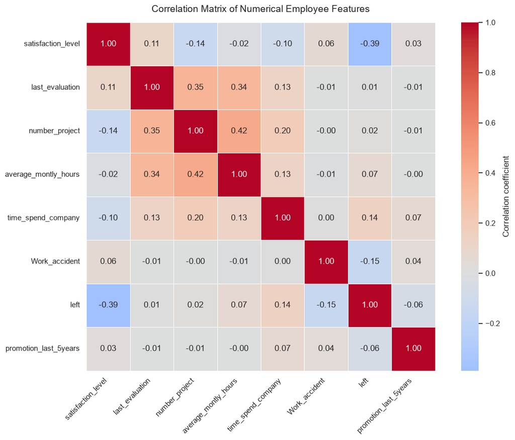

```python
# TODO 2.1: Select numeric columns, calculate their correlation matrix, and draw the heatmap.
# Checkpoint: confirm that categorical columns are not silently included as meaningless codes.

# Select only the numerical features
numeric_columns = df.select_dtypes(include="number").columns

# Identify the categorical columns for verification
categorical_columns = df.select_dtypes(exclude="number").columns

print("Numerical columns included in the correlation matrix:")
print(numeric_columns.tolist())

print("\nCategorical columns excluded from the correlation matrix:")
print(categorical_columns.tolist())

# Calculate the Pearson correlation matrix
correlation_matrix = df[numeric_columns].corr()

# Draw the heatmap
plt.figure(figsize=(12, 9))

sns.heatmap(
    correlation_matrix,
    annot=True,
    fmt=".2f",
    cmap="coolwarm",
    center=0,
    square=True,
    linewidths=0.5,
    cbar_kws={"label": "Correlation coefficient"}
)

plt.title(
    "Correlation Matrix of Numerical Employee Features",
    fontsize=14,
    pad=15
)
plt.xticks(rotation=45, ha="right")
plt.yticks(rotation=0)
plt.tight_layout()
plt.show()
```

### Focused Correlation Analysis: Workload, Tenure, and Turnover

This analysis narrows the correlation matrix to the number of projects, average monthly hours, time spent at the company, and employee turnover. The purpose is to examine the pairwise linear relationships among these closely related workload and tenure features.

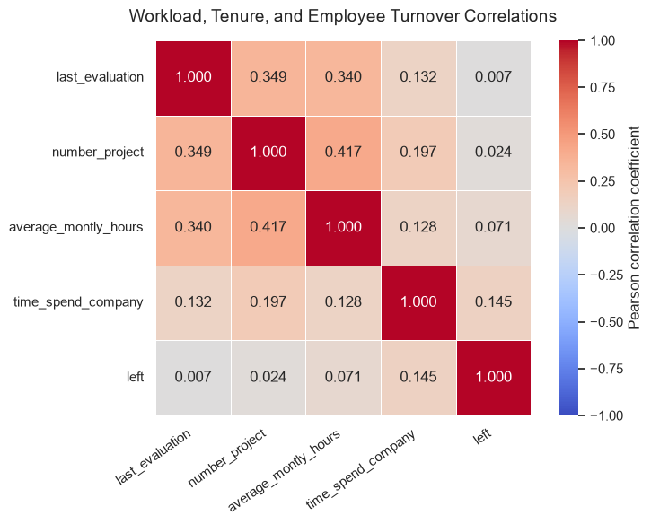

```python
# Select the workload, tenure, and turnover variables
focused_columns = [
    "last_evaluation",
    "number_project",
    "average_montly_hours",
    "time_spend_company",
    "left"
]

# Calculate the focused pairwise correlation matrix
focused_correlation = df[focused_columns].corr()

# Draw the focused heatmap
plt.figure(figsize=(8, 6))

sns.heatmap(
    focused_correlation,
    annot=True,
    fmt=".3f",
    cmap="coolwarm",
    center=0,
    vmin=-1,
    vmax=1,
    square=True,
    linewidths=0.5,
    cbar_kws={"label": "Pearson correlation coefficient"}
)

plt.title(
    "Workload, Tenure, and Employee Turnover Correlations",
    fontsize=14,
    pad=15
)

plt.xticks(rotation=35, ha="right")
plt.yticks(rotation=0)
plt.tight_layout()
plt.show()
```

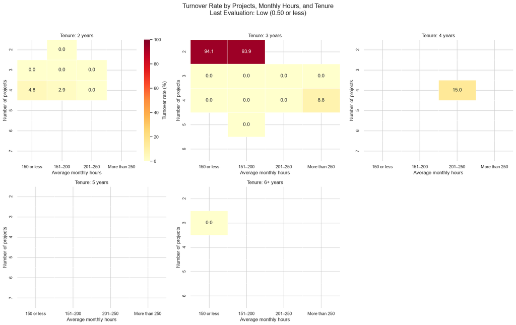

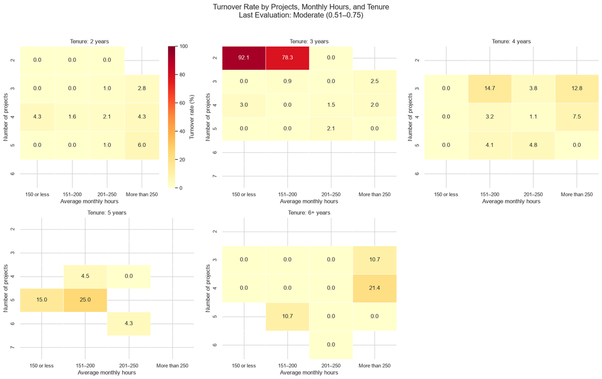

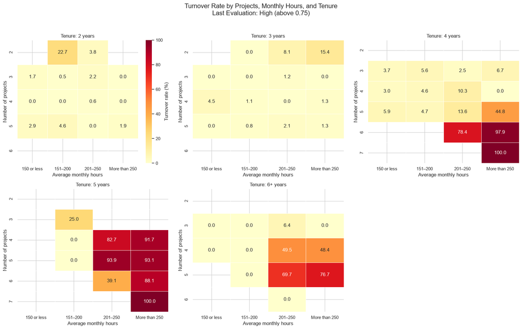

```python
# Create a separate DataFrame for the joint workload analysis
workload_analysis = df[
    [
        "number_project",
        "average_montly_hours",
        "time_spend_company",
        "last_evaluation",
        "left"
    ]
].copy()

# Group average monthly hours into interpretable ranges
workload_analysis["hours_group"] = pd.cut(
    workload_analysis["average_montly_hours"],
    bins=[0, 150, 200, 250, float("inf")],
    labels=[
        "150 or less",
        "151–200",
        "201–250",
        "More than 250"
    ],
    include_lowest=True
)

# Group employee tenure into interpretable ranges
workload_analysis["tenure_group"] = pd.cut(
    workload_analysis["time_spend_company"],
    bins=[0, 2, 3, 4, 5, float("inf")],
    labels=[
        "2 years",
        "3 years",
        "4 years",
        "5 years",
        "6+ years"
    ],
    include_lowest=True
)

# Group evaluation scores into low, moderate, and high categories
workload_analysis["evaluation_group"] = pd.cut(
    workload_analysis["last_evaluation"],
    bins=[0, 0.50, 0.75, 1.00],
    labels=[
        "Low (0.50 or less)",
        "Moderate (0.51–0.75)",
        "High (above 0.75)"
    ],
    include_lowest=True
)

# Preserve the intended category order
tenure_groups = workload_analysis[
    "tenure_group"
].cat.categories

evaluation_groups = workload_analysis[
    "evaluation_group"
].cat.categories

# Produce one figure for each evaluation group
for evaluation in evaluation_groups:

    evaluation_data = workload_analysis[
        workload_analysis["evaluation_group"] == evaluation
    ]

    fig, axes = plt.subplots(
        2,
        3,
        figsize=(18, 11)
    )

    axes = axes.flatten()

    # Produce one panel for each tenure group
    for panel_index, (ax, tenure) in enumerate(
        zip(axes, tenure_groups)
    ):

        panel_data = evaluation_data[
            evaluation_data["tenure_group"] == tenure
        ]

        # Calculate the turnover rate for each
        # project-count and monthly-hours combination
        turnover_rates = panel_data.pivot_table(
            index="number_project",
            columns="hours_group",
            values="left",
            aggfunc="mean",
            observed=False
        ) * 100

        # Count employees in each combination
        observation_counts = panel_data.pivot_table(
            index="number_project",
            columns="hours_group",
            values="left",
            aggfunc="size",
            observed=False
        )

        # Hide combinations containing fewer than 20 employees
        low_sample_mask = observation_counts < 20

        sns.heatmap(
            turnover_rates,
            mask=low_sample_mask,
            annot=True,
            fmt=".1f",
            cmap="YlOrRd",
            vmin=0,
            vmax=100,
            linewidths=0.5,
            cbar=(panel_index == 0),
            cbar_kws={"label": "Turnover rate (%)"},
            ax=ax
        )

        ax.set_title(f"Tenure: {tenure}")
        ax.set_xlabel("Average monthly hours")
        ax.set_ylabel("Number of projects")

    # Remove the unused sixth panel
    for unused_ax in axes[len(tenure_groups):]:
        unused_ax.remove()

    fig.suptitle(
        (
            "Turnover Rate by Projects, Monthly Hours, and Tenure\n"
            f"Last Evaluation: {evaluation}"
        ),
        fontsize=16,
        y=1.02
    )

    plt.tight_layout()
    plt.show()
```

#### Interpretation checkpoint — Question 2.1

- Which numerical features have the strongest correlations with `left`?
- Are those correlations weak, moderate, or strong?
- Which relationships deserve closer visual investigation?

**Write the inference here:**

time spent at the company has the strongest positive correlation with turnover relative to the other features, but it is still only a weak relationship in absolute terms. High-performing employees exposed to sustained heavy workloads—particularly high monthly hours and numerous projects after several years with the company—show a substantially elevated turnover rate. The correlation analysis shows that no single workload or tenure feature has a strong linear relationship with employee turnover. However, the joint analysis reveals important nonlinear patterns that are not visible in the pairwise correlation matrix. Employees with low or moderate evaluations, three years of tenure, two projects, and fewer than 200 monthly hours show high turnover rates, suggesting a potentially underutilized or disengaged employee profile. A second profile appears among highly evaluated employees with four or more years of tenure who are assigned numerous projects and work more than 200 hours per month. Turnover generally increases as both project count and monthly hours rise within this group, suggesting a possible overwork or burnout risk. These explanations cannot be confirmed from the available data, but the observed patterns indicate that employee turnover may depend more on interactions among evaluation, workload, and tenure than on any single feature independently. These relationships should be examined further during predictive modeling.

### 2.2 Draw Distribution Plots

Create distribution plots for:

- Employee satisfaction — `satisfaction_level`
- Employee evaluation — `last_evaluation`
- Average monthly hours — `average_montly_hours`

**Deliverable:** three clearly titled plots with labeled axes. Consider whether showing `left` as a comparison improves the analysis.

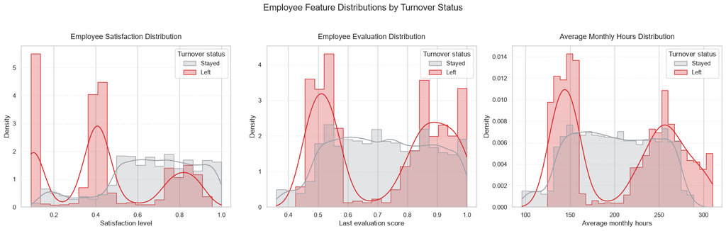

```python
# TODO 2.2: Draw the three required distributions.
# Decide whether to use histograms, KDE curves, or both, and whether to compare stayed vs. left.
# Keep bin choices and axis labels consistent enough to support interpretation.

# Create readable labels for the turnover categories
distribution_df = df.copy()

distribution_df["turnover_status"] = distribution_df["left"].map({
    0: "Stayed",
    1: "Left"
})

# Define the three required features and their plot settings
distribution_features = {
    "satisfaction_level": {
        "title": "Employee Satisfaction Distribution",
        "x_label": "Satisfaction level",
        "bins": 20
    },
    "last_evaluation": {
        "title": "Employee Evaluation Distribution",
        "x_label": "Last evaluation score",
        "bins": 20
    },
    "average_montly_hours": {
        "title": "Average Monthly Hours Distribution",
        "x_label": "Average monthly hours",
        "bins": 30
    }
}

# Use gray as the comparison baseline and emphasize turnover in red
turnover_palette = {
    "Stayed": "#9AA0A6",
    "Left": "#D62728"
}

fig, axes = plt.subplots(
    nrows=1,
    ncols=3,
    figsize=(18, 5.5)
)

for ax, (column, settings) in zip(
    axes,
    distribution_features.items()
):
    sns.histplot(
        data=distribution_df,
        x=column,
        hue="turnover_status",
        hue_order=["Stayed", "Left"],
        bins=settings["bins"],
        kde=True,
        stat="density",
        common_norm=False,
        element="step",
        fill=True,
        alpha=0.28,
        palette=turnover_palette,
        ax=ax
    )

    ax.set_title(
        settings["title"],
        fontsize=13,
        pad=12
    )
    ax.set_xlabel(settings["x_label"])
    ax.set_ylabel("Density")
    ax.grid(
        axis="y",
        linestyle="--",
        alpha=0.25
    )

    legend = ax.get_legend()

    if legend is not None:
        legend.set_title("Turnover status")

fig.suptitle(
    "Employee Feature Distributions by Turnover Status",
    fontsize=16,
    y=1.03
)

plt.tight_layout()
plt.show()
```

#### Interpretation checkpoint — Question 2.2

- Is each distribution symmetric, skewed, multimodal, or clustered?
- Where do employees who left appear concentrated?
- What possible workload or satisfaction patterns should be tested later?

**Write the inference here:**

The distributions reveal several distinct employee-turnover profiles. Satisfaction among employees who stayed is broadly concentrated at moderate-to-high levels, with relatively few employees at very low satisfaction. In contrast, the satisfaction distribution for employees who left is multimodal, with noticeable concentrations near very low satisfaction, around 0.40, and again at higher satisfaction levels. This suggests that turnover is not limited to dissatisfied employees and may occur for different reasons among different employee groups.

The last-evaluation distribution for employees who stayed is broad and relatively balanced rather than strongly skewed. Employees who left show a distinctly bimodal distribution, with one cluster around evaluation scores of 0.50 and another among highly evaluated employees near 0.85–1.00. Average monthly hours show a similar pattern: employees who stayed are distributed broadly around the middle of the range, while employees who left are concentrated in two groups—approximately 130–160 hours and 240–300 hours per month.

Together, these distributions suggest two possible turnover profiles: employees with lower satisfaction, lower evaluations, and comparatively low monthly hours may be underutilized or disengaged, while highly evaluated employees working substantially more hours may be experiencing excessive workload or burnout. These explanations remain hypotheses, but later modeling should test whether satisfaction, evaluation, and monthly hours interact to predict turnover more effectively than any individual feature alone.

The bimodal patterns in the distribution plots are consistent with the two turnover profiles. The joint heatmaps indicated elevated turnover among relatively underloaded employees and among highly evaluated employees experiencing heavier workloads. These distribution plots confirmed that employees who left were concentrated near both the lower and upper ends of evaluation scores and monthly working hours.

### 2.3 Draw the Employee Project-Count Bar Plot for Employees Who Left and Stayed

Use `number_project` on the horizontal axis and `left` as the hue.

**Deliverable:** a grouped count plot plus an explanation of the project-count ranges most associated with turnover.

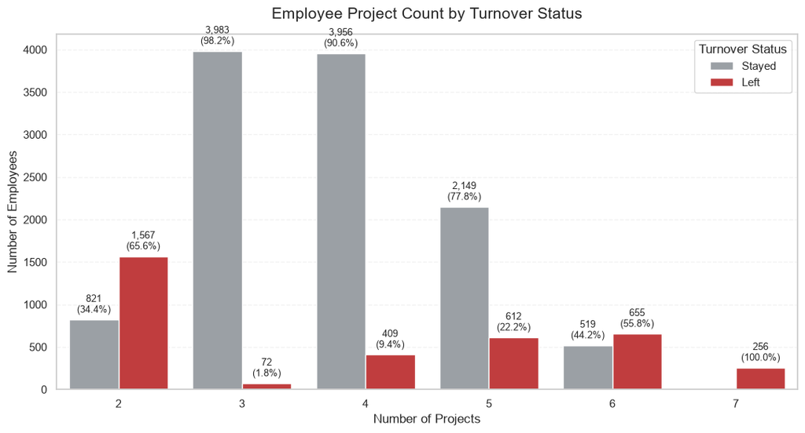

```python
# TODO 2.3: Plot project counts for employees who stayed and left.
# Sanity check: compare raw counts carefully because the two target classes are imbalanced.

# Define the project-count order
project_order = sorted(df["number_project"].unique())

# Calculate raw counts by project count and turnover status
project_counts = pd.crosstab(
    df["number_project"],
    df["left"]
).reindex(
    index=project_order,
    columns=[0, 1],
    fill_value=0
)

# Calculate percentages within each project-count group
project_percentages = (
    project_counts.div(project_counts.sum(axis=1), axis=0) * 100
)

# Draw the grouped bar plot
plt.figure(figsize=(11, 6))

ax = sns.countplot(
    data=df,
    x="number_project",
    hue="left",
    order=project_order,
    hue_order=[0, 1],
    palette={
        0: "#9AA0A6",  # Stayed
        1: "#D62728"   # Left
    }
)

# Add raw counts and within-project percentages above each bar
for container, left_value in zip(ax.containers, [0, 1]):
    for bar, project_count in zip(container, project_order):

        count = project_counts.loc[project_count, left_value]
        percentage = project_percentages.loc[
            project_count,
            left_value
        ]

        ax.annotate(
            f"{count:,}\n({percentage:.1f}%)",
            xy=(
                bar.get_x() + bar.get_width() / 2,
                bar.get_height()
            ),
            xytext=(0, 4),
            textcoords="offset points",
            ha="center",
            va="bottom",
            fontsize=9
        )

ax.set_title(
    "Employee Project Count by Turnover Status",
    fontsize=15,
    pad=15
)

ax.set_xlabel("Number of Projects")
ax.set_ylabel("Number of Employees")

# Replace numeric turnover labels with readable labels
handles, labels = ax.get_legend_handles_labels()

ax.legend(
    handles,
    ["Stayed", "Left"],
    title="Turnover Status"
)

ax.grid(
    axis="y",
    linestyle="--",
    alpha=0.25
)

plt.tight_layout()
plt.show()
```

#### Interpretation checkpoint — Question 2.3

- At which project counts is turnover most visible?
- Does the pattern suggest under-allocation, over-allocation, or both?
- Would percentages reveal anything that raw counts hide?

**Write the inference here:**

Employee turnover is most visible at both the lowest and highest project counts, supporting patterns of both under-allocation and over-allocation. Employees assigned two projects produced the largest raw number of departures, with 1,567 employees leaving and a turnover rate of 65.6%. At the opposite end, all 256 employees assigned seven projects left, producing the highest turnover rate of 100%. Employees assigned six projects also experienced a high turnover rate of 55.8%, while turnover was substantially lower among employees assigned three or four projects. These results confirm the two turnover profiles identified earlier: employees with very few projects may be underutilized or disengaged, while employees with six or seven projects may be experiencing excessive workload. These explanations remain hypotheses because the project-count plot shows association rather than the reasons employees left.

## 3. Cluster Employees Who Left Based on Satisfaction and Evaluation

This section is descriptive: it segments former employees into three behavioral groups. It is separate from the supervised turnover models in Sections 5 and 6.

### 3.1 Choose `satisfaction_level`, `last_evaluation`, and `left`

Filter to employees with `left == 1`, then retain satisfaction and evaluation as the clustering features.

**Deliverable:** the filtered shape and a preview of the two clustering features.

```python
# TODO 3.1: Filter employees who left and create the two-feature clustering matrix.
# Checkpoint: the target column identifies the subset but should not be a K-means input feature.

# Select the required columns
employees_left = df.loc[
    df["left"] == 1,
    [
        "satisfaction_level",
        "last_evaluation",
        "left"
    ]
].copy()

# Retain only the two features that K-means will use
clustering_features = employees_left[
    [
        "satisfaction_level",
        "last_evaluation"
    ]
].copy()

# Display the filtered shape
print(
    "Filtered employee data shape:",
    employees_left.shape
)

print(
    "Clustering feature shape:",
    clustering_features.shape
)

# Preview the two clustering features
clustering_features.head(10)
```

```
Filtered employee data shape: (3571, 3)
Clustering feature shape: (3571, 2)
```

|  | satisfaction_level | last_evaluation |
| --- | --- | --- |
| 0 | 0.38 | 0.53 |
| 1 | 0.80 | 0.86 |
| 2 | 0.11 | 0.88 |
| 3 | 0.72 | 0.87 |
| 4 | 0.37 | 0.52 |
| 5 | 0.41 | 0.50 |
| 6 | 0.10 | 0.77 |
| 7 | 0.92 | 0.85 |
| 8 | 0.89 | 1.00 |
| 9 | 0.42 | 0.53 |

### 3.2 Perform K-Means Clustering of Employees Who Left Into Three Clusters

**Deliverable:** a three-cluster K-means result and a scatter plot of satisfaction versus evaluation, colored by cluster. Marking centroids is recommended.

**Reproducibility:** set a documented `random_state`.

```
Cluster summary:
```

| cluster | employee_count | mean_satisfaction | mean_evaluation |
| --- | --- | --- | --- |
| 0 | 944 | 0.111 | 0.869 |
| 1 | 1650 | 0.410 | 0.517 |
| 2 | 977 | 0.809 | 0.912 |

```
Cluster centroids:
```

| cluster | satisfaction_level | last_evaluation |
| --- | --- | --- |
| 0 | 0.111 | 0.869 |
| 1 | 0.410 | 0.517 |
| 2 | 0.809 | 0.912 |

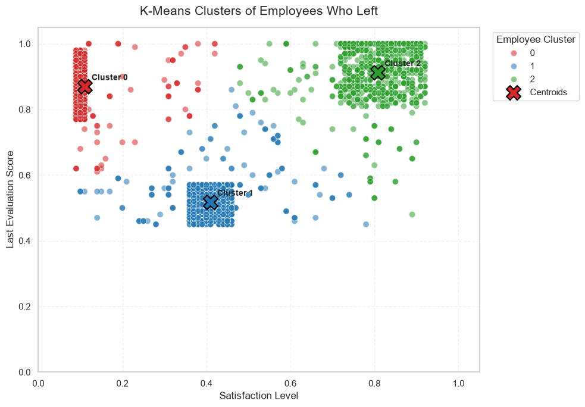

```python
# TODO 3.2: Fit KMeans with n_clusters=3 and visualize the assigned clusters.
# Sanity checks: cluster counts, centroid coordinates, and stable results with a fixed random state.

from sklearn.cluster import KMeans

# Create a K-means model containing three employee clusters
kmeans_model = KMeans(
    n_clusters=3,
    random_state=123,
    n_init=10
)

# Fit the model and assign each departing employee to a cluster
employees_left["cluster"] = kmeans_model.fit_predict(
    clustering_features
)

# Store the cluster centroids
cluster_centroids = pd.DataFrame(
    kmeans_model.cluster_centers_,
    columns=[
        "satisfaction_level",
        "last_evaluation"
    ]
)

cluster_centroids.index.name = "cluster"

# Summarize the three clusters
cluster_summary = employees_left.groupby(
    "cluster"
).agg(
    employee_count=("cluster", "size"),
    mean_satisfaction=("satisfaction_level", "mean"),
    mean_evaluation=("last_evaluation", "mean")
).round(3)

print("Cluster summary:")
display(cluster_summary)

print("Cluster centroids:")
display(cluster_centroids.round(3))

# Define consistent colors for the three clusters
cluster_palette = {
    0: "#D62728",
    1: "#1F77B4",
    2: "#2CA02C"
}

# Plot the employee clusters
plt.figure(figsize=(10, 7))

ax = sns.scatterplot(
    data=employees_left,
    x="satisfaction_level",
    y="last_evaluation",
    hue="cluster",
    palette=cluster_palette,
    alpha=0.55,
    s=55
)

# Plot the centroid of each cluster
plt.scatter(
    cluster_centroids["satisfaction_level"],
    cluster_centroids["last_evaluation"],
    marker="X",
    s=300,
    c=[
        cluster_palette[0],
        cluster_palette[1],
        cluster_palette[2]
    ],
    edgecolor="black",
    linewidth=1.5,
    label="Centroids"
)

# Label each centroid
for cluster_number, centroid in cluster_centroids.iterrows():
    plt.annotate(
        f"Cluster {cluster_number}",
        xy=(
            centroid["satisfaction_level"],
            centroid["last_evaluation"]
        ),
        xytext=(8, 8),
        textcoords="offset points",
        fontsize=10,
        fontweight="bold"
    )

plt.title(
    "K-Means Clusters of Employees Who Left",
    fontsize=15,
    pad=15
)

plt.xlabel("Satisfaction Level")
plt.ylabel("Last Evaluation Score")

plt.xlim(0, 1.05)
plt.ylim(0, 1.05)

plt.legend(
    title="Employee Cluster",
    bbox_to_anchor=(1.02, 1),
    loc="upper left"
)

plt.grid(
    linestyle="--",
    alpha=0.25
)

plt.tight_layout()
plt.show()
```

### 3.3 Explain the Employee Clusters

Summarize each cluster using its centroid, size, and visible position in the plot. Use descriptive labels only after examining the results.

K-means clustering identified three distinct profiles among the 3,571 employees who left the company. Cluster 0 contained 944 employees, or approximately 26.4% of departing employees. Its centroid showed very low average satisfaction of 0.111 and high average evaluation of 0.869. This group represents highly evaluated but deeply dissatisfied employees. Their departure may be associated with inadequate recognition, limited advancement, compensation concerns, excessive workload, or other unmet expectations.

Cluster 1 was the largest group, containing 1,650 employees, or approximately 46.2% of departing employees. These employees had moderate-to-low average satisfaction of 0.410 and a comparatively low average evaluation of 0.517. This profile may represent employees experiencing poor job fit, insufficient support or training, disengagement, or performance difficulties.

Cluster 2 contained 977 employees, or approximately 27.4% of departing employees. Its members had high average satisfaction of 0.809 and high average evaluation of 0.912. This cluster demonstrates that employees may leave even when they appear satisfied and perform well. Their departures may be influenced by workload, compensation, advancement opportunities, competing job offers, or factors not represented in the dataset.

Overall, the clustering analysis confirms that employees who leave do not form one uniform group. Instead, turnover includes highly evaluated but dissatisfied employees, lower-evaluated employees with moderate-to-low satisfaction, and highly satisfied high performers. Consequently, a single retention strategy may not be appropriate for every employee profile. The proposed explanations remain hypotheses because K-means identifies groups based only on satisfaction and evaluation; it does not determine why the employees left or estimate their probability of leaving.

## 4. Handle Class Imbalance Using SMOTE

The positive class (`left == 1`) is the minority class. Preserve an untouched test set and apply SMOTE only to training data.

### 4.1 Convert Categorical Columns to Numerical Columns

The problem statement requires:

1. Separating categorical and numerical variables.
2. Applying `get_dummies()` to categorical variables.
3. Combining the categorical and numerical variables.

**Deliverable:** feature matrix `X`, target vector `y`, encoded shape, and a list of the created dummy columns.

```python
# TODO 4.1: Separate X and y, identify categorical columns, encode them, and recombine features.
# Checkpoint: left must not remain inside X.
# Checkpoint: all final feature columns should be numerical.

# Define the target column
target_column = "left"

# Separate the target from the predictor variables
y = df[target_column].copy()

predictor_df = df.drop(
    columns=[target_column]
).copy()

# Separate categorical and numerical predictor variables
categorical_features = predictor_df.select_dtypes(
    include=["object", "category"]
).copy()

numerical_features = predictor_df.select_dtypes(
    exclude=["object", "category"]
).copy()

# Display the separated feature groups
print(
    "Categorical feature columns:",
    categorical_features.columns.tolist()
)

print(
    "Numerical feature columns:",
    numerical_features.columns.tolist()
)

# Convert categorical variables into numerical dummy variables
categorical_encoded = pd.get_dummies(
    categorical_features,
    dtype=int
)

# Combine the numerical and encoded categorical features
X = pd.concat(
    [
        numerical_features,
        categorical_encoded
    ],
    axis=1
)

# Ensure the target is stored as integers
y = y.astype(int)

# Display the final results
print("\nOriginal dataset shape:", df.shape)
print("Encoded categorical shape:", categorical_encoded.shape)
print("Feature matrix X shape:", X.shape)
print("Target vector y shape:", y.shape)

print("\nFinal feature columns:")
print(X.columns.tolist())

print("\nTarget distribution:")
print(y.value_counts().sort_index())

# Verify that every feature is now numerical
print("\nFeature data types:")
print(X.dtypes.value_counts())

print("\nFeature matrix preview:")
display(X.head())

print("\nTarget vector preview:")
display(y.head())
```

[output not shown]

|  | satisfaction_level | last_evaluation | number_project | average_montly_hours | time_spend_company | Work_accident | promotion_last_5years | sales_IT | sales_RandD | sales_accounting | sales_hr | sales_management | sales_marketing | sales_product_mng | sales_sales | sales_support | sales_technical | salary_high | salary_low | salary_medium |
| --- | --- | --- | --- | --- | --- | --- | --- | --- | --- | --- | --- | --- | --- | --- | --- | --- | --- | --- | --- | --- |
| 0 | 0.38 | 0.53 | 2 | 157 | 3 | 0 | 0 | 0 | 0 | 0 | 0 | 0 | 0 | 0 | 1 | 0 | 0 | 0 | 1 | 0 |
| 1 | 0.80 | 0.86 | 5 | 262 | 6 | 0 | 0 | 0 | 0 | 0 | 0 | 0 | 0 | 0 | 1 | 0 | 0 | 0 | 0 | 1 |
| 2 | 0.11 | 0.88 | 7 | 272 | 4 | 0 | 0 | 0 | 0 | 0 | 0 | 0 | 0 | 0 | 1 | 0 | 0 | 0 | 0 | 1 |
| 3 | 0.72 | 0.87 | 5 | 223 | 5 | 0 | 0 | 0 | 0 | 0 | 0 | 0 | 0 | 0 | 1 | 0 | 0 | 0 | 1 | 0 |
| 4 | 0.37 | 0.52 | 2 | 159 | 3 | 0 | 0 | 0 | 0 | 0 | 0 | 0 | 0 | 0 | 1 | 0 | 0 | 0 | 1 | 0 |

```
Target vector preview:
```

```
0    1
1    1
2    1
3    1
4    1
Name: left, dtype: int64
```

### 4.2 Perform an 80:20 Stratified Train-Test Split With `random_state=123`

**Deliverable:** `X_train`, `X_test`, `y_train`, and `y_test`, plus class proportions showing that stratification worked.

```python
# TODO 4.2: Use an 80:20 split with stratify=y and random_state=123.
# Verify shapes and compare the turnover rate in y, y_train, and y_test.

from sklearn.model_selection import train_test_split

# Split the feature matrix and target vector into
# 80% training data and 20% testing data
X_train, X_test, y_train, y_test = train_test_split(
    X,
    y,
    test_size=0.20,
    stratify=y,
    random_state=123
)

# Verify the shapes of the resulting datasets
print("X_train shape:", X_train.shape)
print("X_test shape:", X_test.shape)
print("y_train shape:", y_train.shape)
print("y_test shape:", y_test.shape)

# Create a comparison of class counts and turnover rates
turnover_comparison = pd.DataFrame(
    [
        {
            "Dataset": "Full Dataset",
            "Employee Count": len(y),
            "Stayed": (y == 0).sum(),
            "Left": (y == 1).sum(),
            "Turnover Rate (%)": y.mean() * 100
        },
        {
            "Dataset": "Training Set",
            "Employee Count": len(y_train),
            "Stayed": (y_train == 0).sum(),
            "Left": (y_train == 1).sum(),
            "Turnover Rate (%)": y_train.mean() * 100
        },
        {
            "Dataset": "Testing Set",
            "Employee Count": len(y_test),
            "Stayed": (y_test == 0).sum(),
            "Left": (y_test == 1).sum(),
            "Turnover Rate (%)": y_test.mean() * 100
        }
    ]
)

# Display the comparison
display(
    turnover_comparison.round(
        {"Turnover Rate (%)": 2}
    )
)
```

```
X_train shape: (11999, 20)
X_test shape: (3000, 20)
y_train shape: (11999,)
y_test shape: (3000,)
```

|  | Dataset | Employee Count | Stayed | Left | Turnover Rate (%) |
| --- | --- | --- | --- | --- | --- |
| 0 | Full Dataset | 14999 | 11428 | 3571 | 23.81 |
| 1 | Training Set | 11999 | 9142 | 2857 | 23.81 |
| 2 | Testing Set | 3000 | 2286 | 714 | 23.80 |

### 4.3 Upsample the Training Dataset Using SMOTE

Import SMOTE from the `imblearn` package and resample the training data only.

**Deliverable:** class counts before and after SMOTE.

> **Leakage guard:** never apply SMOTE to the full dataset or to the test set. For cross-validation, the most defensible design places SMOTE inside an `imblearn` pipeline so synthetic examples are created separately within each training fold.

```python
# TODO 4.3: Apply SMOTE to X_train and y_train only.
# Compare y_train.value_counts() before resampling with the resampled class counts.

from imblearn.over_sampling import SMOTE

# Record the training class counts before SMOTE
class_counts_before = (
    y_train.value_counts()
    .sort_index()
)

# Create and apply SMOTE to the training data only
smote = SMOTE(
    sampling_strategy="auto",
    random_state=123
)

X_train_smote, y_train_smote = smote.fit_resample(
    X_train,
    y_train
)

# Record the class counts after SMOTE
class_counts_after = (
    y_train_smote.value_counts()
    .sort_index()
)

# Compare the class distributions
smote_comparison = pd.DataFrame(
    {
        "Before SMOTE Count": class_counts_before,
        "Before SMOTE (%)": (
            class_counts_before / class_counts_before.sum() * 100
        ),
        "After SMOTE Count": class_counts_after,
        "After SMOTE (%)": (
            class_counts_after / class_counts_after.sum() * 100
        )
    }
)

# Replace the numerical index with readable class labels
smote_comparison.index = [
    "Stayed (0)",
    "Left (1)"
]

# Display shapes and class distribution
print("Training feature shape before SMOTE:", X_train.shape)
print("Training target shape before SMOTE:", y_train.shape)

print("\nTraining feature shape after SMOTE:", X_train_smote.shape)
print("Training target shape after SMOTE:", y_train_smote.shape)

print("\nClass distribution before and after SMOTE:")
display(smote_comparison.round(2))
```

```
Training feature shape before SMOTE: (11999, 20)
Training target shape before SMOTE: (11999,)

Training feature shape after SMOTE: (18284, 20)
Training target shape after SMOTE: (18284,)

Class distribution before and after SMOTE:
```

|  | Before SMOTE Count | Before SMOTE (%) | After SMOTE Count | After SMOTE (%) |
| --- | --- | --- | --- | --- |
| Stayed (0) | 9142 | 76.19 | 9142 | 50.0 |
| Left (1) | 2857 | 23.81 | 9142 | 50.0 |

## 5. Perform 5-Fold Cross-Validation Model Training and Evaluation

Use the same folds and evaluation logic for all three candidate models so the comparison is fair. Keep the held-out test set separate from model selection.

**Suggested evidence for each model:** five-fold scores, mean and standard deviation, holdout predictions, and a classification report.

### 5.1 Train and Evaluate a Logistic Regression Model

Apply five-fold cross-validation and produce the classification report.

**Checkpoint:** if optimization does not converge, investigate feature scaling or the iteration limit rather than ignoring the warning.

```
Logistic Regression five-fold scores:
```

|  | Fold | Accuracy | Precision | Recall | F1 Score |
| --- | --- | --- | --- | --- | --- |
| 0 | 1 | 0.7688 | 0.5092 | 0.7741 | 0.6143 |
| 1 | 2 | 0.7571 | 0.4935 | 0.7968 | 0.6095 |
| 2 | 3 | 0.7633 | 0.5021 | 0.8357 | 0.6273 |
| 3 | 4 | 0.7621 | 0.5005 | 0.8024 | 0.6165 |
| 4 | 5 | 0.7491 | 0.4835 | 0.7951 | 0.6013 |

```
Logistic Regression cross-validation summary:
```

|  | Mean CV Score | Standard Deviation |
| --- | --- | --- |
| Accuracy | 0.7601 | 0.0066 |
| Precision | 0.4978 | 0.0087 |
| Recall | 0.8008 | 0.0199 |
| F1 Score | 0.6138 | 0.0085 |

```
Holdout prediction preview:
```

|  | Actual Class | Predicted Class | Probability of Leaving |
| --- | --- | --- | --- |
| 10627 | 0 | 0 | 0.0842 |
| 2703 | 0 | 1 | 0.8299 |
| 6059 | 0 | 1 | 0.5056 |
| 3258 | 0 | 0 | 0.1948 |
| 4565 | 0 | 0 | 0.3078 |
| 4991 | 0 | 0 | 0.0728 |
| 13976 | 0 | 0 | 0.3672 |
| 9427 | 0 | 0 | 0.1064 |
| 7173 | 0 | 0 | 0.0378 |
| 13412 | 0 | 0 | 0.4323 |

```
Logistic Regression classification report:

              precision    recall  f1-score   support

  Stayed (0)      0.927     0.752     0.830      2286
    Left (1)      0.505     0.810     0.622       714

    accuracy                          0.766      3000
   macro avg      0.716     0.781     0.726      3000
weighted avg      0.826     0.766     0.781      3000

Classification report table:
```

|  | precision | recall | f1-score | support |
| --- | --- | --- | --- | --- |
| Stayed (0) | 0.927 | 0.752 | 0.830 | 2286.000 |
| Left (1) | 0.505 | 0.810 | 0.622 | 714.000 |
| accuracy | 0.766 | 0.766 | 0.766 | 0.766 |
| macro avg | 0.716 | 0.781 | 0.726 | 3000.000 |
| weighted avg | 0.826 | 0.766 | 0.781 | 3000.000 |

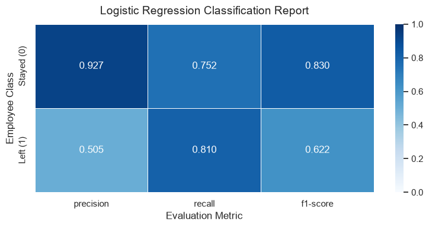

```python
# TODO 5.1: Define, cross-validate, fit, and evaluate Logistic Regression.
# Store the fitted model, predictions, probabilities, CV results, and classification report for Section 6.

import numpy as np
import pandas as pd
import matplotlib.pyplot as plt
import seaborn as sns

from sklearn.linear_model import LogisticRegression
from sklearn.model_selection import (
    StratifiedKFold,
    cross_validate
)
from sklearn.preprocessing import StandardScaler
from sklearn.metrics import classification_report

from imblearn.over_sampling import SMOTE
from imblearn.pipeline import Pipeline


# Create a pipeline that scales the features, applies SMOTE,
# and trains the Logistic Regression model
logistic_pipeline = Pipeline(
    steps=[
        (
            "scaler",
            StandardScaler()
        ),
        (
            "smote",
            SMOTE(
                random_state=123
            )
        ),
        (
            "model",
            LogisticRegression(
                max_iter=1000,
                solver="liblinear",
                random_state=123
            )
        )
    ]
)


# Define reproducible stratified five-fold cross-validation
logistic_cv = StratifiedKFold(
    n_splits=5,
    shuffle=True,
    random_state=123
)


# Evaluate several classification metrics during cross-validation
logistic_scoring = {
    "accuracy": "accuracy",
    "precision": "precision",
    "recall": "recall",
    "f1": "f1"
}


logistic_cv_results = cross_validate(
    estimator=logistic_pipeline,
    X=X_train,
    y=y_train,
    cv=logistic_cv,
    scoring=logistic_scoring,
    n_jobs=-1
)


# Store the score from each fold
logistic_cv_scores = pd.DataFrame(
    {
        "Fold": np.arange(1, 6),
        "Accuracy": logistic_cv_results[
            "test_accuracy"
        ],
        "Precision": logistic_cv_results[
            "test_precision"
        ],
        "Recall": logistic_cv_results[
            "test_recall"
        ],
        "F1 Score": logistic_cv_results[
            "test_f1"
        ]
    }
)


print("Logistic Regression five-fold scores:")
display(
    logistic_cv_scores.round(4)
)


# Calculate the mean and standard deviation across the five folds
metric_columns = [
    "Accuracy",
    "Precision",
    "Recall",
    "F1 Score"
]

logistic_cv_summary = pd.DataFrame(
    {
        "Mean CV Score": logistic_cv_scores[
            metric_columns
        ].mean(),
        "Standard Deviation": logistic_cv_scores[
            metric_columns
        ].std(ddof=0)
    }
)


print("Logistic Regression cross-validation summary:")
display(
    logistic_cv_summary.round(4)
)


# Fit the complete pipeline using the original training data
# The pipeline applies SMOTE internally
logistic_pipeline.fit(
    X_train,
    y_train
)


# Predict the untouched holdout test data
logistic_predictions = logistic_pipeline.predict(
    X_test
)

logistic_probabilities = logistic_pipeline.predict_proba(
    X_test
)[:, 1]


# Preview the holdout predictions
logistic_prediction_preview = pd.DataFrame(
    {
        "Actual Class": y_test,
        "Predicted Class": logistic_predictions,
        "Probability of Leaving": logistic_probabilities
    },
    index=y_test.index
)


print("Holdout prediction preview:")
display(
    logistic_prediction_preview.head(10).round(4)
)


# Generate the holdout classification report
print("Logistic Regression classification report:\n")

print(
    classification_report(
        y_test,
        logistic_predictions,
        labels=[0, 1],
        target_names=[
            "Stayed (0)",
            "Left (1)"
        ],
        digits=3,
        zero_division=0
    )
)


# Convert the classification report into a DataFrame
logistic_report = classification_report(
    y_test,
    logistic_predictions,
    labels=[0, 1],
    target_names=[
        "Stayed (0)",
        "Left (1)"
    ],
    output_dict=True,
    zero_division=0
)

logistic_report_df = pd.DataFrame(
    logistic_report
).transpose()


print("Classification report table:")
display(
    logistic_report_df.round(3)
)


# Plot the primary classification-report metrics
logistic_report_plot = logistic_report_df.loc[
    [
        "Stayed (0)",
        "Left (1)"
    ],
    [
        "precision",
        "recall",
        "f1-score"
    ]
]


plt.figure(
    figsize=(8, 4)
)

sns.heatmap(
    logistic_report_plot,
    annot=True,
    fmt=".3f",
    cmap="Blues",
    vmin=0,
    vmax=1,
    linewidths=0.5
)

plt.title(
    "Logistic Regression Classification Report",
    fontsize=14,
    pad=12
)

plt.xlabel(
    "Evaluation Metric"
)

plt.ylabel(
    "Employee Class"
)

plt.tight_layout()
plt.show()
```

### 5.2 Train and Evaluate a Random Forest Classifier

Apply five-fold cross-validation and produce the classification report. Use a fixed random state.

```
Random Forest five-fold scores:
```

|  | Fold | Accuracy | Precision | Recall | F1 Score |
| --- | --- | --- | --- | --- | --- |
| 0 | 1 | 0.9875 | 0.9839 | 0.9632 | 0.9735 |
| 1 | 2 | 0.9850 | 0.9872 | 0.9492 | 0.9679 |
| 2 | 3 | 0.9871 | 0.9856 | 0.9598 | 0.9725 |
| 3 | 4 | 0.9854 | 0.9855 | 0.9528 | 0.9689 |
| 4 | 5 | 0.9858 | 0.9820 | 0.9580 | 0.9699 |

```
Random Forest cross-validation summary:
```

|  | Mean CV Score | Standard Deviation |
| --- | --- | --- |
| Accuracy | 0.9862 | 0.0010 |
| Precision | 0.9849 | 0.0018 |
| Recall | 0.9566 | 0.0050 |
| F1 Score | 0.9705 | 0.0021 |

```
Random Forest holdout prediction preview:
```

|  | Actual Class | Predicted Class | Probability of Leaving |
| --- | --- | --- | --- |
| 10627 | 0 | 0 | 0.00 |
| 2703 | 0 | 0 | 0.44 |
| 6059 | 0 | 0 | 0.08 |
| 3258 | 0 | 0 | 0.02 |
| 4565 | 0 | 0 | 0.04 |
| 4991 | 0 | 0 | 0.00 |
| 13976 | 0 | 0 | 0.00 |
| 9427 | 0 | 0 | 0.00 |
| 7173 | 0 | 0 | 0.00 |
| 13412 | 0 | 0 | 0.01 |

```
Random Forest classification report:

              precision    recall  f1-score   support

  Stayed (0)      0.993     0.996     0.995      2286
    Left (1)      0.986     0.979     0.982       714

    accuracy                          0.992      3000
   macro avg      0.990     0.987     0.988      3000
weighted avg      0.992     0.992     0.992      3000

Random Forest classification report table:
```

|  | precision | recall | f1-score | support |
| --- | --- | --- | --- | --- |
| Stayed (0) | 0.993 | 0.996 | 0.995 | 2286.000 |
| Left (1) | 0.986 | 0.979 | 0.982 | 714.000 |
| accuracy | 0.992 | 0.992 | 0.992 | 0.992 |
| macro avg | 0.990 | 0.987 | 0.988 | 3000.000 |
| weighted avg | 0.992 | 0.992 | 0.992 | 3000.000 |

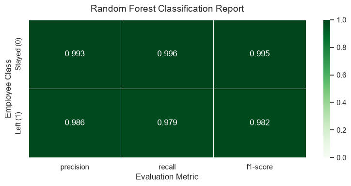

```python
# TODO 5.2: Define, cross-validate, fit, and evaluate Random Forest.
# Store outputs under clear Random Forest names so they cannot overwrite the Logistic Regression results.

from sklearn.ensemble import RandomForestClassifier
from sklearn.model_selection import (
    StratifiedKFold,
    cross_validate
)
from sklearn.preprocessing import StandardScaler
from sklearn.metrics import classification_report

from imblearn.over_sampling import SMOTE
from imblearn.pipeline import Pipeline


# Create the Random Forest pipeline
#
# Random Forest does not require scaling, but SMOTE uses
# distances to locate neighboring observations. Scaling
# prevents large-range features from dominating those distances.
random_forest_pipeline = Pipeline(
    steps=[
        (
            "scaler",
            StandardScaler()
        ),
        (
            "smote",
            SMOTE(
                random_state=123
            )
        ),
        (
            "model",
            RandomForestClassifier(
                n_estimators=100,
                random_state=123
            )
        )
    ]
)


# Define reproducible stratified five-fold cross-validation
random_forest_cv = StratifiedKFold(
    n_splits=5,
    shuffle=True,
    random_state=123
)


# Define the evaluation metrics
random_forest_scoring = {
    "accuracy": "accuracy",
    "precision": "precision",
    "recall": "recall",
    "f1": "f1"
}


# Perform five-fold cross-validation using the original
# training data. SMOTE is applied separately within each fold.
random_forest_cv_results = cross_validate(
    estimator=random_forest_pipeline,
    X=X_train,
    y=y_train,
    cv=random_forest_cv,
    scoring=random_forest_scoring,
    n_jobs=-1
)


# Store the evaluation score from each fold
random_forest_cv_scores = pd.DataFrame(
    {
        "Fold": np.arange(1, 6),
        "Accuracy": random_forest_cv_results[
            "test_accuracy"
        ],
        "Precision": random_forest_cv_results[
            "test_precision"
        ],
        "Recall": random_forest_cv_results[
            "test_recall"
        ],
        "F1 Score": random_forest_cv_results[
            "test_f1"
        ]
    }
)


print("Random Forest five-fold scores:")

display(
    random_forest_cv_scores.round(4)
)


# Calculate the mean and standard deviation across the folds
random_forest_metric_columns = [
    "Accuracy",
    "Precision",
    "Recall",
    "F1 Score"
]


random_forest_cv_summary = pd.DataFrame(
    {
        "Mean CV Score": random_forest_cv_scores[
            random_forest_metric_columns
        ].mean(),

        "Standard Deviation": random_forest_cv_scores[
            random_forest_metric_columns
        ].std(ddof=0)
    }
)


print("Random Forest cross-validation summary:")

display(
    random_forest_cv_summary.round(4)
)


# Fit the complete pipeline using the original training data
# The pipeline applies scaling and SMOTE internally.
random_forest_pipeline.fit(
    X_train,
    y_train
)


# Predict the classes of the untouched holdout test data
random_forest_predictions = random_forest_pipeline.predict(
    X_test
)


# Store the probability that each employee belongs
# to the turnover class, left = 1
random_forest_probabilities = (
    random_forest_pipeline.predict_proba(
        X_test
    )[:, 1]
)


# Preview the holdout predictions and probabilities
random_forest_prediction_preview = pd.DataFrame(
    {
        "Actual Class": y_test,
        "Predicted Class": random_forest_predictions,
        "Probability of Leaving": random_forest_probabilities
    },
    index=y_test.index
)


print("Random Forest holdout prediction preview:")

display(
    random_forest_prediction_preview.head(10).round(4)
)


# Print the classification report
print("Random Forest classification report:\n")

print(
    classification_report(
        y_test,
        random_forest_predictions,
        labels=[0, 1],
        target_names=[
            "Stayed (0)",
            "Left (1)"
        ],
        digits=3,
        zero_division=0
    )
)


# Store the classification report as a DataFrame
random_forest_report = classification_report(
    y_test,
    random_forest_predictions,
    labels=[0, 1],
    target_names=[
        "Stayed (0)",
        "Left (1)"
    ],
    output_dict=True,
    zero_division=0
)


random_forest_report_df = pd.DataFrame(
    random_forest_report
).transpose()


print("Random Forest classification report table:")

display(
    random_forest_report_df.round(3)
)


# Select the class-specific metrics for visualization
random_forest_report_plot = random_forest_report_df.loc[
    [
        "Stayed (0)",
        "Left (1)"
    ],
    [
        "precision",
        "recall",
        "f1-score"
    ]
]


# Plot the classification report
plt.figure(
    figsize=(8, 4)
)

sns.heatmap(
    random_forest_report_plot,
    annot=True,
    fmt=".3f",
    cmap="Greens",
    vmin=0,
    vmax=1,
    linewidths=0.5
)

plt.title(
    "Random Forest Classification Report",
    fontsize=14,
    pad=12
)

plt.xlabel(
    "Evaluation Metric"
)

plt.ylabel(
    "Employee Class"
)

plt.tight_layout()
plt.show()
```

### 5.3 Train and Evaluate a Gradient Boosting Classifier

Apply five-fold cross-validation and produce the classification report. Use a fixed random state when supported.

```
Gradient Boosting five-fold scores:
```

|  | Fold | Accuracy | Precision | Recall | F1 Score |
| --- | --- | --- | --- | --- | --- |
| 0 | 1 | 0.9683 | 0.9335 | 0.9335 | 0.9335 |
| 1 | 2 | 0.9654 | 0.9236 | 0.9317 | 0.9276 |
| 2 | 3 | 0.9671 | 0.9214 | 0.9423 | 0.9317 |
| 3 | 4 | 0.9662 | 0.9270 | 0.9318 | 0.9294 |
| 4 | 5 | 0.9687 | 0.9291 | 0.9405 | 0.9347 |

```
Gradient Boosting cross-validation summary:
```

|  | Mean CV Score | Standard Deviation |
| --- | --- | --- |
| Accuracy | 0.9672 | 0.0012 |
| Precision | 0.9269 | 0.0042 |
| Recall | 0.9359 | 0.0045 |
| F1 Score | 0.9314 | 0.0026 |

```
Gradient Boosting holdout prediction preview:
```

|  | Actual Class | Predicted Class | Probability of Leaving |
| --- | --- | --- | --- |
| 10627 | 0 | 0 | 0.0051 |
| 2703 | 0 | 1 | 0.9164 |
| 6059 | 0 | 0 | 0.0430 |
| 3258 | 0 | 0 | 0.0141 |
| 4565 | 0 | 0 | 0.0205 |
| 4991 | 0 | 0 | 0.0041 |
| 13976 | 0 | 0 | 0.0090 |
| 9427 | 0 | 0 | 0.0080 |
| 7173 | 0 | 0 | 0.0071 |
| 13412 | 0 | 0 | 0.0292 |

```
Gradient Boosting classification report:

              precision    recall  f1-score   support

  Stayed (0)      0.979     0.978     0.979      2286
    Left (1)      0.929     0.934     0.932       714

    accuracy                          0.967      3000
   macro avg      0.954     0.956     0.955      3000
weighted avg      0.967     0.967     0.967      3000

Gradient Boosting classification report table:
```

|  | precision | recall | f1-score | support |
| --- | --- | --- | --- | --- |
| Stayed (0) | 0.979 | 0.978 | 0.979 | 2286.000 |
| Left (1) | 0.929 | 0.934 | 0.932 | 714.000 |
| accuracy | 0.967 | 0.967 | 0.967 | 0.967 |
| macro avg | 0.954 | 0.956 | 0.955 | 3000.000 |
| weighted avg | 0.967 | 0.967 | 0.967 | 3000.000 |

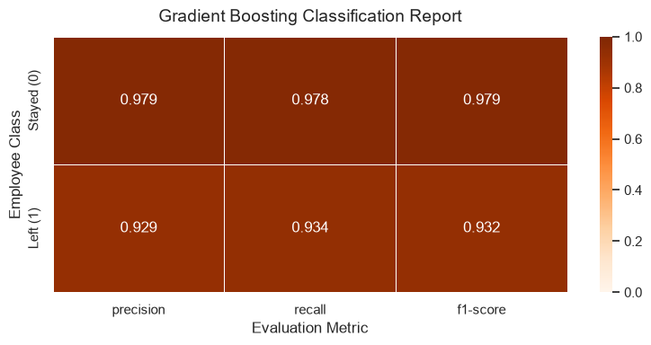

```python
# TODO 5.3: Define, cross-validate, fit, and evaluate Gradient Boosting.
# Store outputs under clear Gradient Boosting names for the Section 6 comparison.

from sklearn.ensemble import GradientBoostingClassifier
from sklearn.model_selection import (
    StratifiedKFold,
    cross_validate
)
from sklearn.preprocessing import StandardScaler
from sklearn.metrics import classification_report

from imblearn.over_sampling import SMOTE
from imblearn.pipeline import Pipeline


# Create the Gradient Boosting pipeline
#
# Gradient Boosting itself does not require scaling.
# StandardScaler is included because SMOTE uses distances
# to identify neighboring minority-class observations.
gradient_boosting_pipeline = Pipeline(
    steps=[
        (
            "scaler",
            StandardScaler()
        ),
        (
            "smote",
            SMOTE(
                random_state=123
            )
        ),
        (
            "model",
            GradientBoostingClassifier(
                n_estimators=100,
                learning_rate=0.1,
                max_depth=3,
                random_state=123
            )
        )
    ]
)


# Define reproducible stratified five-fold cross-validation
gradient_boosting_cv = StratifiedKFold(
    n_splits=5,
    shuffle=True,
    random_state=123
)


# Define the evaluation metrics
gradient_boosting_scoring = {
    "accuracy": "accuracy",
    "precision": "precision",
    "recall": "recall",
    "f1": "f1"
}


# Perform five-fold cross-validation using the original
# training data. SMOTE is applied separately within each fold.
gradient_boosting_cv_results = cross_validate(
    estimator=gradient_boosting_pipeline,
    X=X_train,
    y=y_train,
    cv=gradient_boosting_cv,
    scoring=gradient_boosting_scoring,
    n_jobs=-1
)


# Store the evaluation score from each fold
gradient_boosting_cv_scores = pd.DataFrame(
    {
        "Fold": np.arange(1, 6),
        "Accuracy": gradient_boosting_cv_results[
            "test_accuracy"
        ],
        "Precision": gradient_boosting_cv_results[
            "test_precision"
        ],
        "Recall": gradient_boosting_cv_results[
            "test_recall"
        ],
        "F1 Score": gradient_boosting_cv_results[
            "test_f1"
        ]
    }
)


print("Gradient Boosting five-fold scores:")

display(
    gradient_boosting_cv_scores.round(4)
)


# Calculate the mean and standard deviation across the folds
gradient_boosting_metric_columns = [
    "Accuracy",
    "Precision",
    "Recall",
    "F1 Score"
]


gradient_boosting_cv_summary = pd.DataFrame(
    {
        "Mean CV Score": gradient_boosting_cv_scores[
            gradient_boosting_metric_columns
        ].mean(),

        "Standard Deviation": gradient_boosting_cv_scores[
            gradient_boosting_metric_columns
        ].std(ddof=0)
    }
)


print("Gradient Boosting cross-validation summary:")

display(
    gradient_boosting_cv_summary.round(4)
)


# Fit the complete pipeline using the original training data.
# The pipeline applies scaling and SMOTE internally.
gradient_boosting_pipeline.fit(
    X_train,
    y_train
)


# Predict the classes of the untouched holdout test data
gradient_boosting_predictions = (
    gradient_boosting_pipeline.predict(
        X_test
    )
)


# Store each employee's probability of belonging
# to the turnover class, left = 1
gradient_boosting_probabilities = (
    gradient_boosting_pipeline.predict_proba(
        X_test
    )[:, 1]
)


# Preview the holdout predictions and probabilities
gradient_boosting_prediction_preview = pd.DataFrame(
    {
        "Actual Class": y_test,
        "Predicted Class": gradient_boosting_predictions,
        "Probability of Leaving":
            gradient_boosting_probabilities
    },
    index=y_test.index
)


print("Gradient Boosting holdout prediction preview:")

display(
    gradient_boosting_prediction_preview
    .head(10)
    .round(4)
)


# Print the classification report
print("Gradient Boosting classification report:\n")

print(
    classification_report(
        y_test,
        gradient_boosting_predictions,
        labels=[0, 1],
        target_names=[
            "Stayed (0)",
            "Left (1)"
        ],
        digits=3,
        zero_division=0
    )
)


# Store the classification report as a dictionary
gradient_boosting_report = classification_report(
    y_test,
    gradient_boosting_predictions,
    labels=[0, 1],
    target_names=[
        "Stayed (0)",
        "Left (1)"
    ],
    output_dict=True,
    zero_division=0
)


# Convert the classification report into a DataFrame
gradient_boosting_report_df = pd.DataFrame(
    gradient_boosting_report
).transpose()


print("Gradient Boosting classification report table:")

display(
    gradient_boosting_report_df.round(3)
)


# Select the class-specific metrics for visualization
gradient_boosting_report_plot = (
    gradient_boosting_report_df.loc[
        [
            "Stayed (0)",
            "Left (1)"
        ],
        [
            "precision",
            "recall",
            "f1-score"
        ]
    ]
)


# Plot the classification report
plt.figure(
    figsize=(8, 4)
)

sns.heatmap(
    gradient_boosting_report_plot,
    annot=True,
    fmt=".3f",
    cmap="Oranges",
    vmin=0,
    vmax=1,
    linewidths=0.5
)

plt.title(
    "Gradient Boosting Classification Report",
    fontsize=14,
    pad=12
)

plt.xlabel(
    "Evaluation Metric"
)

plt.ylabel(
    "Employee Class"
)

plt.tight_layout()
plt.show()
```

```python
# For the Checkpoint:

# Create the model-training checkpoint comparison
model_training_checkpoint = pd.DataFrame(
    {
        "Model": [
            "Logistic Regression",
            "Random Forest",
            "Gradient Boosting"
        ],
        "Mean 5-Fold Accuracy": [
            logistic_cv_summary.loc[
                "Accuracy", "Mean CV Score"
            ],
            random_forest_cv_summary.loc[
                "Accuracy", "Mean CV Score"
            ],
            gradient_boosting_cv_summary.loc[
                "Accuracy", "Mean CV Score"
            ]
        ],
        "CV Variability (SD)": [
            logistic_cv_summary.loc[
                "Accuracy", "Standard Deviation"
            ],
            random_forest_cv_summary.loc[
                "Accuracy", "Standard Deviation"
            ],
            gradient_boosting_cv_summary.loc[
                "Accuracy", "Standard Deviation"
            ]
        ],
        "Holdout Precision — Left (1)": [
            logistic_report_df.loc[
                "Left (1)", "precision"
            ],
            random_forest_report_df.loc[
                "Left (1)", "precision"
            ],
            gradient_boosting_report_df.loc[
                "Left (1)", "precision"
            ]
        ],
        "Holdout Recall — Left (1)": [
            logistic_report_df.loc[
                "Left (1)", "recall"
            ],
            random_forest_report_df.loc[
                "Left (1)", "recall"
            ],
            gradient_boosting_report_df.loc[
                "Left (1)", "recall"
            ]
        ],
        "Holdout F1 — Left (1)": [
            logistic_report_df.loc[
                "Left (1)", "f1-score"
            ],
            random_forest_report_df.loc[
                "Left (1)", "f1-score"
            ],
            gradient_boosting_report_df.loc[
                "Left (1)", "f1-score"
            ]
        ]
    }
).set_index("Model")


# Display all metrics as percentages
display(
    model_training_checkpoint.style
    .format("{:.2%}")
    .set_caption(
        "Model Training Checkpoint"
    )
    .highlight_max(
        axis=0,
        color="lightgreen"
    )
    .highlight_min(
        subset=["CV Variability (SD)"],
        color="lightgreen"
    )
)
```

Model Training Checkpoint

| Model | Mean 5-Fold Accuracy | CV Variability (SD) | Holdout Precision — Left (1) | Holdout Recall — Left (1) | Holdout F1 — Left (1) |
| --- | --- | --- | --- | --- | --- |
| Logistic Regression | 76.01% | 0.66% | 50.48% | 80.95% | 62.18% |
| Random Forest | 98.62% | 0.10% | 98.59% | 97.90% | 98.24% |
| Gradient Boosting | 96.72% | 0.12% | 92.90% | 93.42% | 93.16% |

## 6. Identify the Best Model and Justify the Evaluation Metrics

Select the best model using consistent evidence rather than accuracy alone. Employee turnover is imbalanced, so emphasize performance on employees who actually leave.

### 6.1 Find ROC/AUC for Each Model and Plot the ROC Curves

**Deliverable:** all three ROC curves on one plot, a diagonal baseline, and each model's AUC in the legend. Use probability scores, not predicted class labels.

```
ROC-AUC comparison:
```

|  | Model | ROC-AUC Score |
| --- | --- | --- |
| 0 | Random Forest | 0.9949 |
| 1 | Gradient Boosting | 0.9862 |
| 2 | Logistic Regression | 0.8268 |

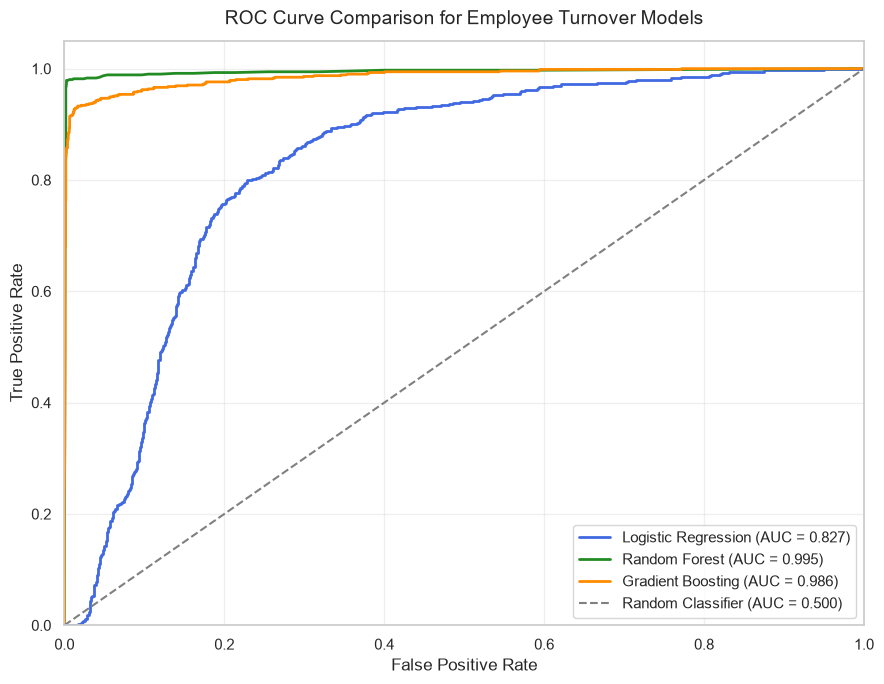

```python
# TODO 6.1: Calculate ROC coordinates and AUC from each model's positive-class probabilities.
# Plot all models on the same axes for a direct comparison.

from sklearn.metrics import (
    roc_curve,
    roc_auc_score
)


# Calculate each model's ROC coordinates
logistic_fpr, logistic_tpr, logistic_thresholds = roc_curve(
    y_test,
    logistic_probabilities
)

random_forest_fpr, random_forest_tpr, random_forest_thresholds = roc_curve(
    y_test,
    random_forest_probabilities
)

gradient_boosting_fpr, gradient_boosting_tpr, gradient_boosting_thresholds = roc_curve(
    y_test,
    gradient_boosting_probabilities
)


# Calculate each model's area under the ROC curve
logistic_auc = roc_auc_score(
    y_test,
    logistic_probabilities
)

random_forest_auc = roc_auc_score(
    y_test,
    random_forest_probabilities
)

gradient_boosting_auc = roc_auc_score(
    y_test,
    gradient_boosting_probabilities
)


# Store the AUC scores in a comparison table
auc_comparison = pd.DataFrame(
    {
        "Model": [
            "Logistic Regression",
            "Random Forest",
            "Gradient Boosting"
        ],
        "ROC-AUC Score": [
            logistic_auc,
            random_forest_auc,
            gradient_boosting_auc
        ]
    }
).sort_values(
    by="ROC-AUC Score",
    ascending=False
).reset_index(
    drop=True
)


print("ROC-AUC comparison:")

display(
    auc_comparison.round(4)
)


# Plot all three ROC curves
plt.figure(
    figsize=(9, 7)
)

plt.plot(
    logistic_fpr,
    logistic_tpr,
    color="royalblue",
    linewidth=2,
    label=f"Logistic Regression (AUC = {logistic_auc:.3f})"
)

plt.plot(
    random_forest_fpr,
    random_forest_tpr,
    color="forestgreen",
    linewidth=2,
    label=f"Random Forest (AUC = {random_forest_auc:.3f})"
)

plt.plot(
    gradient_boosting_fpr,
    gradient_boosting_tpr,
    color="darkorange",
    linewidth=2,
    label=f"Gradient Boosting (AUC = {gradient_boosting_auc:.3f})"
)


# Add the random-classification baseline
plt.plot(
    [0, 1],
    [0, 1],
    color="gray",
    linestyle="--",
    linewidth=1.5,
    label="Random Classifier (AUC = 0.500)"
)


plt.title(
    "ROC Curve Comparison for Employee Turnover Models",
    fontsize=14,
    pad=12
)

plt.xlabel(
    "False Positive Rate"
)

plt.ylabel(
    "True Positive Rate"
)

plt.xlim(
    [0.0, 1.0]
)

plt.ylim(
    [0.0, 1.05]
)

plt.legend(
    loc="lower right"
)

plt.grid(
    alpha=0.3
)

plt.tight_layout()
plt.show()
```

#### Interpretation checkpoint — Question 6.1

- Which model has the highest AUC?
- Are the differences practically meaningful?
- Does the ROC comparison agree with the classification reports?

**Write the inference here:**

The Random Forest achieved the highest ROC-AUC score, indicating the strongest overall ability to distinguish between employees who stayed and those who left. However, its advantage over Gradient Boosting was small and is not practically meaningful, as both models demonstrated excellent discrimination. In contrast, both ensemble models substantially outperformed Logistic Regression. The ROC-AUC comparison agrees with the classification reports: Random Forest performed best overall, Gradient Boosting was a close second, and Logistic Regression was clearly the weakest model. This agreement is based on the models’ relative ranking, not on the numerical closeness of AUC and accuracy, because those metrics measure different aspects of performance.

### 6.2 Find the Confusion Matrix for Each Model

**Deliverable:** three labeled confusion-matrix heatmaps with the same class order and color scale where practical.

Label the cells conceptually as true negatives, false positives, false negatives, and true positives.

```
Confusion-matrix outcome summary:
```

|  | Model | True Negatives | False Positives | False Negatives | True Positives |
| --- | --- | --- | --- | --- | --- |
| 0 | Logistic Regression | 1719 | 567 | 136 | 578 |
| 1 | Random Forest | 2276 | 10 | 15 | 699 |
| 2 | Gradient Boosting | 2235 | 51 | 47 | 667 |

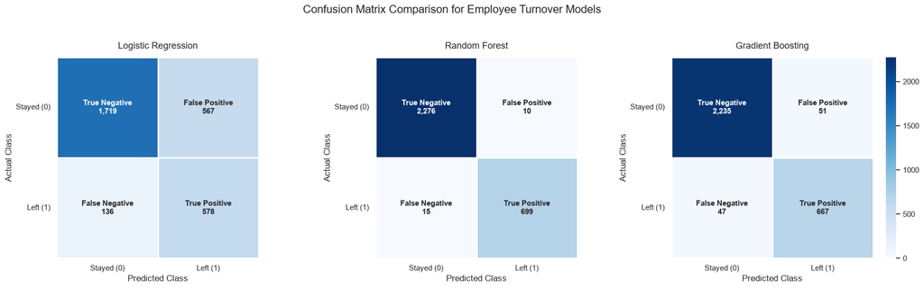

```python
# TODO 6.2: Calculate and plot one confusion matrix for each model.
# Verify that rows represent actual classes and columns represent predicted classes.


from sklearn.metrics import confusion_matrix


# Calculate confusion matrices using the same class order
logistic_confusion_matrix = confusion_matrix(
    y_test,
    logistic_predictions,
    labels=[0, 1]
)

random_forest_confusion_matrix = confusion_matrix(
    y_test,
    random_forest_predictions,
    labels=[0, 1]
)

gradient_boosting_confusion_matrix = confusion_matrix(
    y_test,
    gradient_boosting_predictions,
    labels=[0, 1]
)


# Store the matrices with their model names
confusion_matrices = {
    "Logistic Regression": logistic_confusion_matrix,
    "Random Forest": random_forest_confusion_matrix,
    "Gradient Boosting": gradient_boosting_confusion_matrix
}


# Create a table containing the four confusion-matrix outcomes
confusion_matrix_summary = pd.DataFrame(
    [
        {
            "Model": model_name,
            "True Negatives": matrix[0, 0],
            "False Positives": matrix[0, 1],
            "False Negatives": matrix[1, 0],
            "True Positives": matrix[1, 1]
        }
        for model_name, matrix in confusion_matrices.items()
    ]
)


print("Confusion-matrix outcome summary:")

display(
    confusion_matrix_summary
)


# Use the same color scale across all three heatmaps
maximum_count = max(
    matrix.max()
    for matrix in confusion_matrices.values()
)


fig, axes = plt.subplots(
    1,
    3,
    figsize=(19, 5.5)
)


for index, (model_name, matrix) in enumerate(
    confusion_matrices.items()
):

    # Label each cell with its conceptual meaning and count
    cell_labels = np.array(
        [
            [
                f"True Negative\n{matrix[0, 0]:,}",
                f"False Positive\n{matrix[0, 1]:,}"
            ],
            [
                f"False Negative\n{matrix[1, 0]:,}",
                f"True Positive\n{matrix[1, 1]:,}"
            ]
        ]
    )


    sns.heatmap(
        matrix,
        annot=cell_labels,
        fmt="",
        cmap="Blues",
        vmin=0,
        vmax=maximum_count,
        cbar=(index == 2),
        linewidths=1,
        linecolor="white",
        square=True,
        annot_kws={
            "fontsize": 11,
            "fontweight": "bold"
        },
        ax=axes[index]
    )


    axes[index].set_title(
        model_name,
        fontsize=13,
        pad=12
    )

    axes[index].set_xlabel(
        "Predicted Class"
    )

    axes[index].set_ylabel(
        "Actual Class"
    )

    axes[index].set_xticklabels(
        [
            "Stayed (0)",
            "Left (1)"
        ],
        rotation=0
    )

    axes[index].set_yticklabels(
        [
            "Stayed (0)",
            "Left (1)"
        ],
        rotation=0
    )


fig.suptitle(
    "Confusion Matrix Comparison for Employee Turnover Models",
    fontsize=16,
    y=1.03
)

plt.tight_layout()
plt.show()
```